# Airbnb

```python
# Importing libraries
import pandas as pd
import numpy as np
import seaborn as sns
import matplotlib.pyplot as plt

from sklearn.model_selection import train_test_split

from sklearn.linear_model import LinearRegression
from sklearn.metrics import mean_squared_error, r2_score

import warnings
warnings.filterwarnings('ignore')
```

### Importing the dataset

```python
df=pd.read_csv("Airbnb.csv")
```

### Displaying the first 5 rows of the dataset

```python
df.head()
```

|  | id | room_type | accommodates | bathrooms | cancellation_policy | cleaning_fee | instant_bookable | review_scores_rating | bedrooms | beds | log_price |
| --- | --- | --- | --- | --- | --- | --- | --- | --- | --- | --- | --- |
| 0 | 6901257 | Entire home/apt | 3.0 | 1.0 | strict | True | f | 100.0 | 1.0 | 1.0 | 5.010635 |
| 1 | 6304928 | Entire home/apt | 7.0 | 1.0 | strict | True | t | 93.0 | 3.0 | 3.0 | 5.129899 |
| 2 | 7919400 | Entire home/apt | 5.0 | 1.0 | moderate | True | t | 92.0 | 1.0 | 3.0 | 4.976734 |
| 3 | 13418779 | Entire home/apt | 4.0 | 1.0 | flexible | True | f | NaN | 2.0 | 2.0 | 6.620073 |
| 4 | 3808709 | Entire home/apt | 2.0 | 1.0 | moderate | True | t | 40.0 | 0.0 | 1.0 | 4.744932 |

### Displaying the last 5 rows of the dataset

```python
df.tail()
```

|  | id | room_type | accommodates | bathrooms | cancellation_policy | cleaning_fee | instant_bookable | review_scores_rating | bedrooms | beds | log_price |
| --- | --- | --- | --- | --- | --- | --- | --- | --- | --- | --- | --- |
| 74106 | 14549287 | Private room | 1.0 | 1.0 | flexible | False | f | NaN | 1.0 | 1.0 | 4.605170 |
| 74107 | 13281809 | Entire home/apt | 4.0 | 2.0 | moderate | True | f | 93.0 | 2.0 | 4.0 | 5.043425 |
| 74108 | 18688039 | Entire home/apt | 5.0 | 1.0 | moderate | True | t | 94.0 | 2.0 | 2.0 | 5.220356 |
| 74109 | 17045948 | Entire home/apt | 2.0 | 1.0 | strict | True | t | NaN | 0.0 | 2.0 | 5.273000 |
| 74110 | 3534845 | Entire home/apt | 4.0 | 1.0 | moderate | False | f | 96.0 | 1.0 | 2.0 | 4.852030 |

### Checking the shape of the dataset

```python
df.shape
```

```
(74111, 11)
```

Observations:

- There are 74111 rows and 11 columns in the dataset

### Checking the data types of the columns

```python
df.info()
```

```
<class 'pandas.core.frame.DataFrame'>
RangeIndex: 74111 entries, 0 to 74110
Data columns (total 11 columns):
 #   Column                Non-Null Count  Dtype
---  ------                --------------  -----
 0   id                    74111 non-null  int64
 1   room_type             74106 non-null  object
 2   accommodates          74108 non-null  float64
 3   bathrooms             73908 non-null  float64
 4   cancellation_policy   74103 non-null  object
 5   cleaning_fee          74107 non-null  object
 6   instant_bookable      74111 non-null  object
 7   review_scores_rating  57389 non-null  float64
 8   bedrooms              74019 non-null  float64
 9   beds                  73980 non-null  float64
 10  log_price             74111 non-null  float64
dtypes: float64(6), int64(1), object(4)
memory usage: 6.2+ MB
```

### Checking if null values are present in the dataset

```python
df.isnull().sum()
```

|  | 0 |
| --- | --- |
| id | 0 |
| room_type | 5 |
| accommodates | 3 |
| bathrooms | 203 |
| cancellation_policy | 8 |
| cleaning_fee | 4 |
| instant_bookable | 0 |
| review_scores_rating | 16722 |
| bedrooms | 92 |
| beds | 131 |
| log_price | 0 |

**dtype:** int64

### Checking if duplicated values are present in the dataset

```python
df.duplicated().sum()
```

```
np.int64(0)
```

Observation

- There are no duplicate values in the dataset

### Dropping the ID column

```python
df = df.drop(columns=['id'], errors='ignore')
```

### Imputing the missing values with the median values and categorical column values with mode

```python
# Select numeric columns
numeric_cols = df.select_dtypes(include=['int64', 'float64']).columns

# Fill missing numeric values with median
df[numeric_cols] = df[numeric_cols].fillna(df[numeric_cols].median())
```

```python
categorical_cols = ['room_type','cancellation_policy','cleaning_fee']

for cols in categorical_cols:
  df[cols] = df[cols].fillna(df[cols].mode()[0])
```

```python
df.head()
```

|  | room_type | accommodates | bathrooms | cancellation_policy | cleaning_fee | instant_bookable | review_scores_rating | bedrooms | beds | log_price |
| --- | --- | --- | --- | --- | --- | --- | --- | --- | --- | --- |
| 0 | Entire home/apt | 3.0 | 1.0 | strict | True | f | 100.0 | 1.0 | 1.0 | 5.010635 |
| 1 | Entire home/apt | 7.0 | 1.0 | strict | True | t | 93.0 | 3.0 | 3.0 | 5.129899 |
| 2 | Entire home/apt | 5.0 | 1.0 | moderate | True | t | 92.0 | 1.0 | 3.0 | 4.976734 |
| 3 | Entire home/apt | 4.0 | 1.0 | flexible | True | f | 96.0 | 2.0 | 2.0 | 6.620073 |
| 4 | Entire home/apt | 2.0 | 1.0 | moderate | True | t | 40.0 | 0.0 | 1.0 | 4.744932 |

```python
df.tail()
```

|  | room_type | accommodates | bathrooms | cancellation_policy | cleaning_fee | instant_bookable | review_scores_rating | bedrooms | beds | log_price |
| --- | --- | --- | --- | --- | --- | --- | --- | --- | --- | --- |
| 74106 | Private room | 1.0 | 1.0 | flexible | False | f | 96.0 | 1.0 | 1.0 | 4.605170 |
| 74107 | Entire home/apt | 4.0 | 2.0 | moderate | True | f | 93.0 | 2.0 | 4.0 | 5.043425 |
| 74108 | Entire home/apt | 5.0 | 1.0 | moderate | True | t | 94.0 | 2.0 | 2.0 | 5.220356 |
| 74109 | Entire home/apt | 2.0 | 1.0 | strict | True | t | 96.0 | 0.0 | 2.0 | 5.273000 |
| 74110 | Entire home/apt | 4.0 | 1.0 | moderate | False | f | 96.0 | 1.0 | 2.0 | 4.852030 |

```python
df.isnull().sum()
```

|  | 0 |
| --- | --- |
| room_type | 0 |
| accommodates | 0 |
| bathrooms | 0 |
| cancellation_policy | 0 |
| cleaning_fee | 0 |
| instant_bookable | 0 |
| review_scores_rating | 0 |
| bedrooms | 0 |
| beds | 0 |
| log_price | 0 |

**dtype:** int64

### Exploratory data analysis

### Univariate analysis

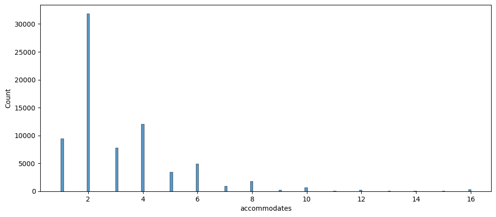

```python
plt.figure(figsize=(12,5))
sns.histplot(df['accommodates'])
plt.show()
```

Observations:

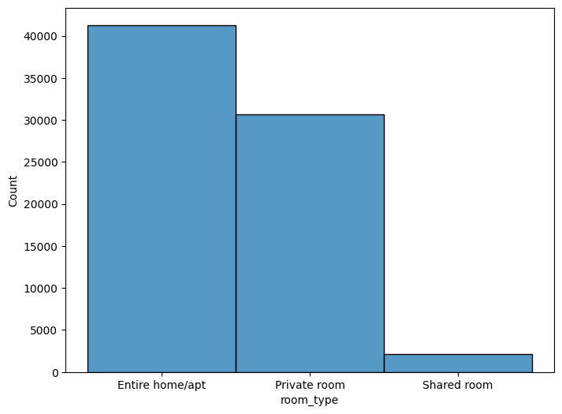

```python
plt.figure(figsize=(8,6))
sns.histplot(df['room_type'])
plt.show()
```

Observation:

- The dataset contains the highest number of home/apt as compared to private room and shared rooms
- Entire home/apt are greater than 40000 in number

```python
numeric_df = df.select_dtypes(include=['int64','float64'])
```

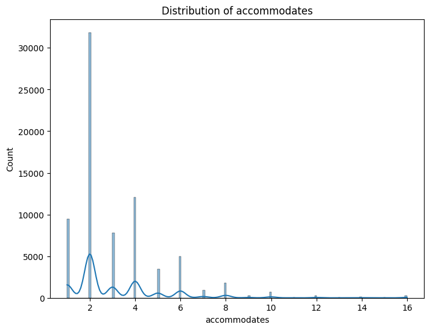

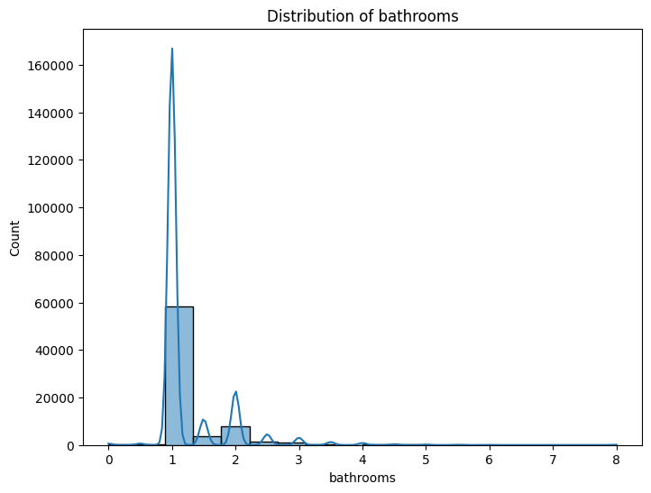

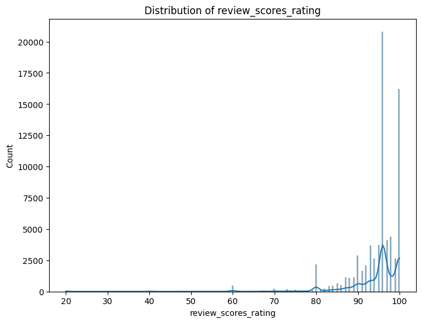

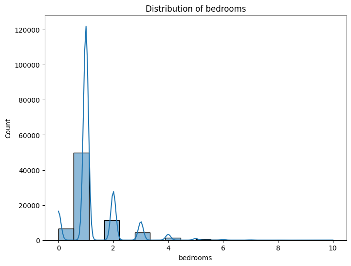

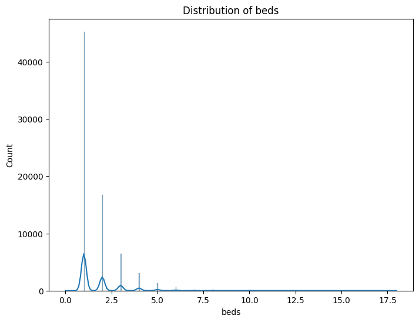

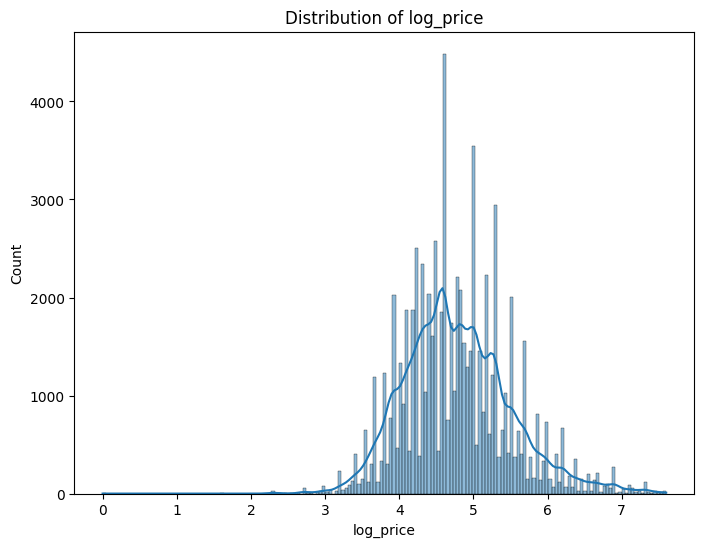

```python
for col in numeric_df.columns:
  plt.figure(figsize=(8,6))
  sns.histplot(df[col], kde=True)
  plt.title(f"Distribution of {col}")
  plt.show()
```

Observations:

- Highest number of accommodates is 2
- Highest number of properties have 1 bathroom
- Most of the properties have review ratings greater than 80
- Most of the properties have 1 bedroom
- Highest number of properties atr having log price around 4.6

### Bivariate analysis

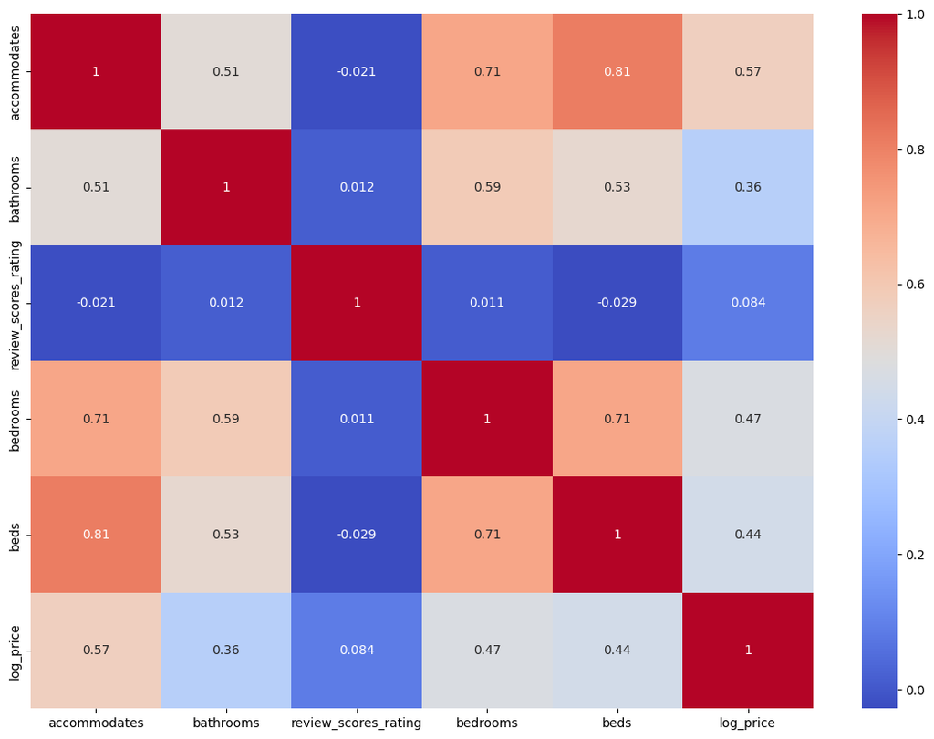

```python
plt.figure(figsize=(14, 10))
sns.heatmap(numeric_df.corr(), annot=True, cmap='coolwarm')
plt.show()
```

Observations:

- Beds is highly correlated with accommodates with a positive correlation of 0.81
- Bedroom is highly correlated with bed with a positive correlation of 0.71
- Beds is negatively correlated with review score rating

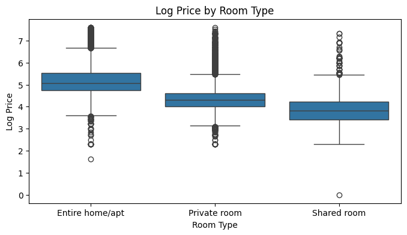

```python
plt.figure(figsize=(8, 4))
sns.boxplot(x='room_type', y='log_price', data=df)
plt.title('Log Price by Room Type')
plt.xlabel('Room Type')
plt.ylabel('Log Price')
plt.show()
```

Observations:

- All the different type of properties have outliers
- The median of log price of the entire home/apt is higher compared to private room and shared room

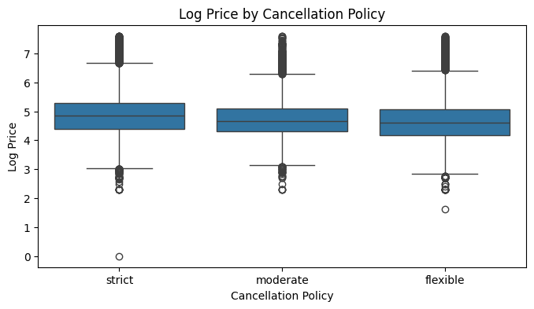

```python
plt.figure(figsize=(8, 4))
sns.boxplot(x='cancellation_policy', y='log_price', data=df)
plt.title('Log Price by Cancellation Policy')
plt.xlabel('Cancellation Policy')
plt.ylabel('Log Price')
plt.show()
```

Observations:

- All the different type of cancellation policies have outliers
- Strict cancellation policy have higher log price as compared to moderate and flexible cancellation policy

### Encoding the categorical columns

```python
categorical_cols = ['room_type', 'cancellation_policy', 'cleaning_fee', 'instant_bookable']

df_encoded = pd.get_dummies(df, columns=categorical_cols, drop_first=True)
```

```python
df_encoded.head()
```

|  | accommodates | bathrooms | review_scores_rating | bedrooms | beds | log_price | room_type_Private room | room_type_Shared room | cancellation_policy_moderate | cancellation_policy_strict | cleaning_fee_True | instant_bookable_t |
| --- | --- | --- | --- | --- | --- | --- | --- | --- | --- | --- | --- | --- |
| 0 | 3.0 | 1.0 | 100.0 | 1.0 | 1.0 | 5.010635 | False | False | False | True | True | False |
| 1 | 7.0 | 1.0 | 93.0 | 3.0 | 3.0 | 5.129899 | False | False | False | True | True | True |
| 2 | 5.0 | 1.0 | 92.0 | 1.0 | 3.0 | 4.976734 | False | False | True | False | True | True |
| 3 | 4.0 | 1.0 | 96.0 | 2.0 | 2.0 | 6.620073 | False | False | False | False | True | False |
| 4 | 2.0 | 1.0 | 40.0 | 0.0 | 1.0 | 4.744932 | False | False | True | False | True | True |

### Dividing the dataset in X and Y

```python
X=df_encoded.drop('log_price',axis=1)
y=df_encoded['log_price']
```

Dividing the dataset into training and testing sets

```python
X_train, X_test, y_train, y_test=train_test_split(X,y,test_size=0.2,random_state=1)
```

Instantiating the model

```python
model=LinearRegression()
```

```python
model.fit(X_train,y_train)
```

```
LinearRegression()
```

```python
y_pred_test = model.predict(X_test)
```

```python
mse_log = mean_squared_error(y_test, y_pred_test)
rmse_log = np.sqrt(mse_log)
r2 = r2_score(y_test, y_pred_test)

print(f"Log-scale RMSE: {rmse_log:.4f}")
print(f"R^2 (log scale): {r2:.4f}")
```

```
Log-scale RMSE: 0.5006
R^2 (log scale): 0.5183
```

Plotting the actual vs predicted log price

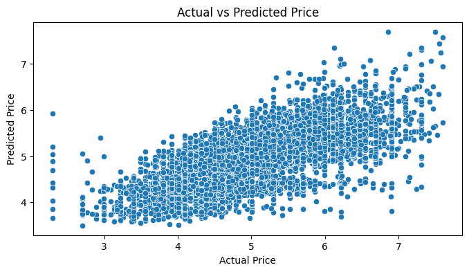

```python
plt.figure(figsize=(8,4))
sns.scatterplot(x=y_test, y=y_pred_test)
plt.xlabel('Actual Price')
plt.ylabel('Predicted Price')
plt.title('Actual vs Predicted Price')
plt.show()
```

Observations:

- Majority of the datapoints are concentrated between the interval 3-6 log price

### Features impacting the log price

```python
coefficient = pd.DataFrame({'Feature':X.columns,'Coefficient':model.coef_}).sort_values(by='Coefficient',ascending=False)
print(f"Top positive features are:\n", coefficient.head())
print(f"Top negative features are:\n", coefficient.tail())
```

```
Top positive features are:
                       Feature  Coefficient
3                    bedrooms     0.151223
1                   bathrooms     0.145303
0                accommodates     0.079938
2        review_scores_rating     0.007142
8  cancellation_policy_strict    -0.007373
Top negative features are:
                          Feature  Coefficient
10            instant_bookable_t    -0.054862
7   cancellation_policy_moderate    -0.055831
9              cleaning_fee_True    -0.069937
5         room_type_Private room    -0.639969
6          room_type_Shared room    -1.102300
```